# Extract morphology data from SALI

Lauren O’Brien

2019-12-12

```r
options(stringsAsFactors = FALSE, scipen = 999)
library(sf)            # vector data IO and processing
library(DBI)           # database interface
library(ROracle)       # Oracle database drivers
library(getPass)       # password management
library(units)         # for working with unit-attributed data
library(tidyverse)     # general data manipulation and display
library(RSQLite)       # local db write

Sys.setenv(
  'TNS_ADMIN'   = file.path('C:', 'Users', Sys.getenv('USERNAME'), 'Oracle'),
  'ORACLE_HOME' = 'C:/Program Files/Oracle Instant Client'
  )
SALI <- dbConnect(dbDriver('Oracle'),
                  username = 'obrienle',
                  password = getPass(),
                  dbname   = 'sispda',
                  host     = 'ex02client01',
                  port     = 1521)

if(!dir.exists(file.path(getwd(), 'SALI_DATA'))) {
  dir.create(file.path(getwd(), 'SALI_DATA'))
}
```

## Data snapshot

Take a snapshot of SALI sites module to work with offline. Filter on data that’s allowed out - from published projects where QC has been completed.

The data-holding tables in the sites module are structured as follows:

- 1 SIT_SITES
  - 2 SIT_SITE_LAND_USES
  - 3 SIT_SITE_MAN_PRACS
  - 4 SIT_ELEM_GEOMORPHS
  - 5 SIT_PATT_GEOMORPHS
  - 6 SIT_NOTES
  - 7 SIT_OBSERVATIONS
    - 8 SIT_LOCATIONS
    - 9 SIT_SOIL_CLASSIFICATIONS
    - 10 SIT_DISTURBANCES
    - 11 SIT_SURFACE_CONDITIONS
    - 12 SIT_MICRORELIEFS
    - 13 SIT_EROSIONS
    - 14 SIT_SURF_COARSE_FRAGS
    - 15 SIT_ROCK_OUTCROPS
    - 16 SIT_SUB_MINERAL_COMPS
    - 17 SIT_VEG_COMMUNITIES
      - 18 SIT_VEG_STRATA
      - 19 SIT_VEG_STRATA_SPECIES
    - 20 SIT_HORIZONS
      - 21 SIT_HORIZON_SUFFICES
      - 22 SIT_HORIZON_COLOURS
      - 23 SIT_MOTTLES
      - 24 SIT_COARSE_FRAGS
      - 25 SIT_STRUCTURES
      - 26 SIT_SEGREGATIONS
      - 27 SIT_FABRICS
      - 28 SIT_CUTANS
      - 29 SIT_CRACKS
      - 30 SIT_MACROPORES
      - 31 SIT_STRENGTHS
      - 32 SIT_PANS
      - 33 SIT_ROOTS
      - 34 SIT_FIELD_TESTS
    - 35 SIT_SAMPLES
      - 36 SIT_LAB_RESULTS

Some additional tables hold decodes (meanings) for the coded data and are extracted separately below.

```r
today <- '20191212' # edit for fresh snapshot

sit_datafile <- file.path(getwd(), 'SALI_DATA',
                          paste0('SALI_SIT-data_', today, '.rds'))

# restricts to projects that are allowed out
temp1 <- c("with temp1 as (
             select project_code from reg_projects
             where site_qc_status = 'P'
             and avail_status = 'E') ")

if(file.exists(sit_datafile)) {
  sit_data <- readRDS(sit_datafile)
} else {
  sit_data <-
    list(
      # 1 - Sites
      "SIT" =
        dbGetQuery(SALI,
         paste0(temp1,
                "select * from temp1
                 inner join sit_sites using (project_code)
                 order by project_code, site_id")),
      # 2 - Land Uses
      # Contemporary to date(s) of observation(s) - these are not updated
      "SLU" =
        dbGetQuery(SALI,
         paste0(temp1,
                "select * from temp1
                 inner join sit_site_land_uses using (project_code)
                 order by project_code, site_id, land_use_no")),
      # 3 site management practices
      "SMP" =
        dbGetQuery(SALI,
         paste0(temp1,
                "select * from temp1
                 inner join sit_site_man_pracs using (project_code)
                 order by project_code, site_id, man_prac_no")),
      # 4 Geomorphology at element scale (radius 20m around site)
      "SGE" =
        dbGetQuery(SALI,
         paste0(temp1,
                "select * from temp1
                 inner join sit_elem_geomorphs using (project_code)
                 order by project_code, site_id, elem_geo_no")),
      # 5 Geomorphology at pattern scale (radius 300m around site)
      "SGP" =
        dbGetQuery(SALI,
         paste0(temp1,
                "select * from temp1
                 inner join sit_patt_geomorphs using (project_code)
                 order by project_code, site_id, patt_geo_no")),
      # 6 Notes
      # NB Site, Obs and Hor notes all live in the one table but can be
      # keyed out easily by note_type
      # CFD notes are excluded as they contain names/phone numbers/addresses
      "NOT" =
        dbGetQuery(SALI,
         paste0(temp1,
                "select * from temp1
                 inner join sit_notes using (project_code)
                 where note_type != 'CFD'
                 order by project_code, site_id")),
      # 7 - Observations
      "OBS" =
        dbGetQuery(SALI,
          paste0(temp1,
            "select * from temp1
             inner join sit_observations using (project_code)
             order by project_code, site_id, obs_no")),
      # 8 Locations
      # grabbing all but SHAPE col below, ROracle can't handle SDO_GEOM :'(
      # also only grabbing coordinates in GDA94 (EPSG:4283). Some of these are
      # converted in the system, having originally been recorded in AGD84 or
      # AGD66 datums, often in projected systems (commonly UTM zone 55S or 56S)
      "OLC" =
        dbGetQuery(SALI,
          paste0(temp1,
            "select project_code, site_id, obs_no, datum, derived_location,
             zone, easting, northing, longitude, latitude, loc_accuracy,
             created_by, creation_date, last_updated_by, last_update_date
             from temp1
             inner join sit_locations using (project_code)
             where datum = 3
             and longitude > 1 and longitude is not null  /* >:-( */
             order by project_code, site_id, obs_no")),
      # 9 Soil Classifications
      "OCL" =
        dbGetQuery(SALI,
          paste0(temp1,
            "select * from temp1
             inner join sit_soil_classifications using (project_code)
             order by project_code, site_id, obs_no, soil_class_no")),
      # 10 Disturbances
      "ODS" =
        dbGetQuery(SALI,
          paste0(temp1,
                 "select * from temp1
                  inner join sit_disturbances using (project_code)
                  order by project_code, site_id, obs_no, disturb_no")),
      # 11 surface conditions
      "OSC" =
        dbGetQuery(SALI,
          paste0(temp1,
                 "select * from temp1
                  inner join sit_surf_conditions using (project_code)
                  order by project_code, site_id, obs_no, surf_cond_no")),
      # 12 Microrelief
      "OMC" =
        dbGetQuery(SALI,
          paste0(temp1,
                 "select * from temp1
                  inner join sit_microreliefs using (project_code)
                  order by project_code, site_id, obs_no, micro_no")),
      # 13 Erosion
      "OER" =
        dbGetQuery(SALI,
          paste0(temp1,
                 "select * from temp1
                  inner join sit_erosions using (project_code)
                  order by project_code, site_id, obs_no, ero_no")),
      # 14 Surface Coarse Frags
      "OCF" =
        dbGetQuery(SALI,
          paste0(temp1,
                 "select * from temp1
                  inner join sit_surf_coarse_frags using (project_code)
                  order by project_code, site_id, obs_no, surf_frag_no")),
      # 15 Outcrop
      "OTC" =
        dbGetQuery(SALI,
          paste0(temp1,
                 "select * from temp1
                  inner join sit_rock_outcrops using (project_code)
                  order by project_code, site_id, obs_no, outcrop_no")),
      # 16 substrate mineral composition
      "OSM" =
        dbGetQuery(SALI,
          paste0(temp1,
                 "select * from temp1
                  inner join sit_sub_mineral_comps using (project_code)
                  order by project_code, site_id, obs_no, sub_min_no")),
      # 17 Vegetation communities
      "VCM" =
        dbGetQuery(SALI,
          paste0(temp1,
                 "select * from temp1
                  inner join sit_veg_communities using (project_code)
                  order by project_code, site_id, obs_no, veg_comm_no")),
      # 18 Veg strata
      "VST" =
        dbGetQuery(SALI,
          paste0(temp1,
                 "select * from temp1
                  inner join sit_veg_strata using (project_code)
                  order by project_code, site_id, obs_no, veg_comm_no")),
      # 19 veg spp
      "VSP" =
        dbGetQuery(SALI,
            paste0(temp1,
                   "select * from temp1
                    inner join sit_veg_strata_species using (project_code)
                    order by project_code, site_id, obs_no, veg_comm_no,
                      veg_strata_spec_no")),
      # 20 soil horizons
      "HOR" =
        dbGetQuery(SALI,
          paste0(temp1,
            "select hor.*, (texture_code || texture_qualifier) as texture
             from temp1
             inner join sit_horizons hor
               on temp1.project_code = hor.project_code
             order by hor.project_code, site_id, obs_no, horizon_no")),
      # 21 horizon suffices
      "HSX" =
        dbGetQuery(SALI,
          paste0(temp1,
                 "select * from temp1
                  inner join sit_horizon_suffices using (project_code)
                  order by project_code, site_id, obs_no, horizon_no")),
      # 22 Horizon colours
      "HCO" =
        dbGetQuery(SALI,
          paste0(temp1,
                 "select * from temp1
                  inner join sit_horizon_colours using (project_code)
                  order by project_code, site_id, obs_no, horizon_no,
                    hor_col_no")),
      # 23 mottles
      "HMT" =
        dbGetQuery(SALI,
          paste0(temp1,
                 "select * from temp1
                  inner join sit_mottles using (project_code)
                  order by project_code, site_id, obs_no, horizon_no,
                    mott_no")),
      # 24 coarse frags
      "HCF" =
        dbGetQuery(SALI,
         paste0(temp1,
                "select * from temp1
                inner join sit_coarse_frags using (project_code)
                order by project_code, site_id, obs_no, horizon_no,
                  coarse_frag_no")),
      # 25 Stuctures
      "HST" =
        dbGetQuery(SALI,
            paste0(temp1,
                   "select * from temp1
                    inner join sit_structures using (project_code)
                    order by project_code, site_id, obs_no, horizon_no,
                      struct_no")),
      # 26 Segregations
      "HSG" =
        dbGetQuery(SALI,
            paste0(temp1,
                   "select * from temp1
                    inner join sit_segregations using (project_code)
                    order by project_code, site_id, obs_no, horizon_no,
                      seg_no")),
      # 27 Fabrics
      "HFB" =
        dbGetQuery(SALI,
          paste0(temp1,
                 "select * from temp1
                  inner join sit_fabrics using (project_code)
                  order by project_code, site_id, obs_no, horizon_no,
                    fab_no")),
      # 28 Cutans
      "HCU" =
        dbGetQuery(SALI,
          paste0(temp1,
                 "select * from temp1
                  inner join sit_cutans using (project_code)
                  order by project_code, site_id, obs_no, horizon_no,
                    cutan_no")),
      # 29 Cracks
      "HCR" =
        dbGetQuery(SALI,
          paste0(temp1,
                 "select * from temp1
                  inner join sit_cracks using (project_code)
                  order by project_code, site_id, obs_no, horizon_no,
                    crack_no")),
      # 30 Macropores
      "HMP" =
        dbGetQuery(SALI,
            paste0(temp1,
                   "select * from temp1
                    inner join sit_macropores using (project_code)
                    order by project_code, site_id, obs_no, horizon_no,
                      macro_no")),
      # 31 Strengths
      "HGT" =
        dbGetQuery(SALI,
            paste0(temp1,
                   "select * from temp1
                    inner join sit_strengths using (project_code)
                    order by project_code, site_id, obs_no, horizon_no,
                      stren_no")),
      # 32 Pans
      "HPA" =
        dbGetQuery(SALI,
            paste0(temp1,
                   "select * from temp1
                    inner join sit_pans using (project_code)
                    order by project_code, site_id, obs_no, horizon_no,
                      pan_no")),
      # 33 Roots
      "HRT" =
        dbGetQuery(SALI,
            paste0(temp1,
                   "select * from temp1
                    inner join sit_roots using (project_code)
                    order by project_code, site_id, obs_no, horizon_no,
                      root_no")),
      # 34 Field tests
      "FTS" =
         dbGetQuery(SALI,
          paste0(temp1,
                 "select * from temp1
                  inner join sit_field_tests using (project_code)
                  order by project_code, site_id, obs_no, horizon_no,
                    test_no")),
      # 35 Samples
      # note - can join with keys including horizon but don't have to
      "SAM" =
        dbGetQuery(SALI,
          paste0(temp1,
                 "select * from temp1
                  inner join sit_samples using (project_code)
                  order by project_code, site_id, obs_no, sample_no")),
      # 36 lab results
      "LAB" =
        dbGetQuery(SALI,
          paste0(temp1,
                 "select * from temp1
                  inner join sit_lab_results using (project_code)
                  order by project_code, site_id, obs_no, sample_no"))
      )
  saveRDS(sit_data, sit_datafile)
}
```

### Decode Tables

Decodes for short code lists are all in one large table called `SALI_REF_CODES`, grouped by field `RV_DOMAIN`. See `'/helpers/REF_CODE_DOMAINS_for_sites.xlsx'` for some contextual info.

Longer code lists e.g. geology, landform elements are in their own tables

1. SALI_REF_CODES (used all over)
2. SIT_ELEM_TYPES
3. SIT_PATT_TYPES
4. SIT_GEOLOGIES
5. SIT_LAND_USES
6. SIT_LITHOLOGIES
7. SIT_MASS_GEN_TYPES
8. SIT_ASCS
9. SIT_PPFS
10. SIT_GSGS
11. SIT_EROSION_TYPES
12. SIT_EROSION_DEGREES
13. SIT_VEG_SPECIES
14. SIT_STRUCT_FORMS
15. SIT_TEXTURES
16. SIT_COLOURS
17. SIT_COLOUR_CONVERT
18. SIT_FACIES
19. SIT_FIELD_TEST_TYPES
20. SIT_FIELD_TEST_TYPE_SPECS
21. SIT_NOTE_TYPES

```r
site_domains <-
  c('AGGRADATION', 'ASC CONFIDENCE', 'ASC FAMILIES', 'ASC ORDERS',
    'ASC_FAMILY_LEVEL', 'BIOTIC AGENTS', 'BIOTIC COMPONENTS',
    'BOUNDARY DISTINCT', 'BOUNDARY SHAPES', 'CARBONATE EFF',
    'COARSE FRAG ABUND', 'COARSE FRAG DISTRIB', 'COARSE FRAG SHAPES',
    'COARSE FRAG SIZES', 'COLOUR BOOKS', 'COND DEGREE', 'CONTRASTS',
    'CRACK WIDTHS', 'CUTAN ABUND', 'CUTAN DISTINCT', 'CUTAN TYPES',
    'DISP METHODS', 'DISPERSIONS', 'DISPERSIONS2', 'DISTURBANCE TYPES',
    'DRAINAGE', 'EC METHODS', 'ECSE METHODS', 'ELEM INC SLOPE',
    'ELEM LOCATIONS', 'ELEVATION EVALUATIONS', 'EROSION GULLY DEPTHS',
    'EROSION STATES', 'FABRIC TYPES', 'FIELD TEXT GRADE', 'FOREST TYPES',
    'GEOMORPH AGENTS', 'GEOMORPH MODES', 'GEOMORPH STATUS',
    'GILGAI PROPORTIONS', 'H2O2 REACTIONS', 'HORIZON MASTERS',
    'HORIZON SUFFIXES', 'INUND DEPTHS', 'INUND DURATIONS', 'INUND FREQ',
    'INUND RUNON VEL', 'MAP REF TYPES', 'METHOD DOMAINS',
    'MICRORELIEF COMPONENT', 'MICRORELIEF TYPES', 'MINERAL COMP', 'MODAL SLOPE',
    'MOISTURE STATUS', 'MORPH TYPES', 'MOTT ABUND', 'MOTT BOUND DISTINCT',
    'MOTT SIZES', 'MOTT TYPES', 'NOTE INFO TYPES', 'OBS ANALYSIS STATUS',
    'OBS LOC MEASURE METH', 'OBS REASONS', 'OBS TYPES', 'PAN CEMENTATIONS',
    'PAN CONTINUITY', 'PAN STRUCTURES', 'PAN TYPES', 'PERMEABILITY',
    'PH METHODS', 'PHOTO TYPES', 'PLASTICITY DEGREE', 'PLASTICITY TYPES',
    'PORE ABUND', 'PORE DIAMETERS', 'RAINFOREST COMPLEXITY',
    'RAINFOREST FLOR COMP', 'RAINFOREST INDICATOR GROW',
    'RAINFOREST LEAF SIZES', 'RELIEF CLASS', 'RELIEF MODAL SLOPE CLASS',
    'RIPENESS', 'ROCK OUTCROP ABUND', 'ROOT ABUND', 'ROOT SIZES', 'RUNOFF',
    'SAMP DATA SOURCES', 'SAMPLE STATUS', 'SCLEROPHYLL', 'SEG ABUND',
    'SEG FORMS', 'SEG MAGNETIC ATTR', 'SEG NATURES', 'SEG SIZES',
    'SEG STRENGTHS', 'SITE MAN PRACS', 'SITE TYPES', 'SLAK METHODS', 'SLAKING',
    'SLAKING METHOD 1', 'SLAKING METHOD 2', 'SLAKING2', 'SLOPE CLASS',
    'SLOPE EVALUATION', 'SOIL WATER STATUS', 'STICKINESS', 'STRENGTH CLASS',
    'STRENGTHS', 'STRM CHAN DEPTH WIDTH', 'STRM CHAN DEVELOPMENT',
    'STRM CHAN MIGRATION', 'STRM CHAN NET DIRECT', 'STRM CHAN NET INTEG',
    'STRM CHAN PATTERNS', 'STRM CHAN SPACING', 'STRUC CLODS FRAGS',
    'STRUC COMPOUND PED', 'STRUC PED GRADES', 'STRUC PED SIZES',
    'STRUC PED TYPES', 'SUBS CONFIDENCE', 'SUBS GRAIN SIZES',
    'SUBS MASS ALTERATION', 'SUBS MASS SPACE DISCONT', 'SUBS MASS STRENGTHS',
    'SUBS OBS TYPES', 'SUBS POROSITY', 'SUBS SPEC FEATURES', 'SUBS STRUCTURES',
    'SUBS TEXTURES', 'SURF CONDITION STATUS', 'TAX UNIT TYPES',
    'TEXTURE QUALIFIERS', 'VEG STRAT COVER CLASS', 'VEG STRAT GROW FORMS',
    'VEG STRAT HEIGHT CLASS', 'VEG STRATA CODES', 'WATER REPELLENCE',
    'WRB SOIL GROUP', 'LAB METH UNITS', 'LAB RESULT QC CODES',
    'LAB RESULT STATUS', 'LAB SAMPLE STATUS')

decode_datafile <- file.path(getwd(), 'SALI_DATA',
                             paste0('SALI_SIT-data_decodes_', today, '.rds'))

if(file.exists(decode_datafile)) {
  decodes <- readRDS(decode_datafile)
} else {
  decodes <-
    list(
      # SALI ref codes holds all the short lists
      "SRC" =
        dbGetQuery(SALI,
                   "select * from sali_ref_codes
                    order by rv_domain, rv_low_value"
        ) %>%
        # not all domains are relevant to sites and there's also some mess I'm
        # sweeping under rug here >.>
        dplyr::filter(RV_DOMAIN %in% site_domains),
      "ELE" = dbGetQuery(SALI, "select * from sit_elem_types"),
      "PAT" = dbGetQuery(SALI, "select * from sit_patt_types"),
      "GEO" = dbGetQuery(SALI, "select * from sit_geologies"),
      "LUS" = dbGetQuery(SALI, "select * from sit_land_uses"),
      "LTH" = dbGetQuery(SALI, "select * from sit_lithologies"),
      "MGT" = dbGetQuery(SALI, "select * from sit_mass_gen_types"),
      "ASC" = dbGetQuery(SALI, "select * from sit_ascs"),
      "PPF" = dbGetQuery(SALI, "select * from sit_ppfs"),
      "GSG" = dbGetQuery(SALI, "select * from sit_gsgs"),
      "ERT" = dbGetQuery(SALI, "select * from sit_erosion_types"),
      "ERD" = dbGetQuery(SALI, "select * from sit_erosion_degrees"),
      "VSS" = dbGetQuery(SALI, "select * from sit_veg_species"),
      "VST" = dbGetQuery(SALI, "select * from sit_struct_forms"),
      "TEX" = dbGetQuery(SALI, "select * from sit_textures"),
      "COL" = dbGetQuery(SALI, "select * from sit_colours"),
      "CLV" = dbGetQuery(SALI, "select * from sit_colour_convert"),
      "FAC" = dbGetQuery(SALI, "select * from sit_facies"),
      "FTT" = dbGetQuery(SALI, "select * from sit_field_test_types"),
      "FTS" = dbGetQuery(SALI, "select * from sit_field_test_type_specs"),
      "NTP" = dbGetQuery(SALI, "select * from sit_note_types"),
      "LAB" = dbGetQuery(SALI, "select * from sit_labs"),
      "LMT" = dbGetQuery(SALI, "select * from sit_lab_methods")
    )
  saveRDS(decodes, decode_datafile)
}
```

### Make a multilayer geopackage

Because why not?

```r
# make locations spatial
SIT_LOCATIONS <- st_as_sf(sit_data[['OLC']],
                          coords = c('LONGITUDE', 'LATITUDE'),
                          crs = 4283, remove = FALSE,
                          dim = 'XY')
```

```r
# write locations to gpkg
st_write(SIT_LOCATIONS,
         file.path(getwd(), 'SALI_DATA',
                   paste0('SALI_SITES_', format(Sys.Date(), '%Y%m%d'), '.gpkg')),
         layer = 'SIT_LOCATIONS',
         driver = 'GPKG', delete_dsn = TRUE)

# pop locations from main list and rename
sit_data[['OLC']] <- NULL

table_names <- c('SIT_SITES', 'SIT_SITE_LAND_USES', 'SIT_SITE_MAN_PRACS',
                 'SIT_ELEM_GEOMORPHS', 'SIT_PATT_GEOMORPHS', 'SIT_NOTES',
                 'SIT_OBSERVATIONS', 'SIT_SOIL_CLASSIFICATIONS',
                 'SIT_DISTURBANCES', 'SIT_SURFACE_CONDITIONS', 'SIT_MICRORELIEFS',
                 'SIT_EROSIONS',  'SIT_SURF_COARSE_FRAGS', 'SIT_ROCK_OUTCROPS',
                 'SIT_SUB_MINERAL_COMPS', 'SIT_VEG_COMMUNITIES', 'SIT_VEG_STRATA',
                 'SIT_VEG_STRATA_SPECIES', 'SIT_HORIZONS', 'SIT_HORIZON_SUFFICES',
                 'SIT_HORIZON_COLOURS', 'SIT_MOTTLES', 'SIT_COARSE_FRAGS',
                 'SIT_STRUCTURES', 'SIT_SEGREGATIONS', 'SIT_FABRICS', 'SIT_CUTANS',
                 'SIT_CRACKS', 'SIT_MACROPORES', 'SIT_STRENGTHS', 'SIT_PANS',
                 'SIT_ROOTS', 'SIT_FIELD_TESTS', 'SIT_SAMPLES', 'SIT_LAB_RESULTS')
names(sit_data) <- table_names

# do the same for decode tables - note name change, should make the tables
# easier to work with. I always struggle to remember which tables
# actually hold data vs decodes...
decode_names <- c('REF_CODES', 'REF_ELEM_TYPES', 'REF_PATT_TYPES',
                  'REF_GEOLOGIES', 'REF_LAND_USES', 'REF_LITHOLOGIES',
                  'REF_MASS_GEN_TYPES', 'REF_ASCS', 'REF_PPFS', 'REF_GSGS',
                  'REF_EROSION_TYPES', 'REF_EROSION_DEGREES', 'REF_VEG_SPECIES',
                  'REF_STRUCT_FORMS', 'REF_TEXTURES', 'REF_COLOURS',
                  'REF_COLOUR_CONVERT', 'REF_FACIES', 'REF_FIELD_TEST_TYPES',
                  'REF_FIELD_TEST_TYPE_SPECS', 'REF_NOTE_TYPES',
                  'REF_LABS', 'REF_LAB_METHODS')
names(decodes) <- decode_names

# add to gpkg
con <- dbConnect(SQLite(),
                 dbname = file.path(getwd(),'SALI_DATA',
                                    paste0('SALI_SITES_',
                                           format(Sys.Date(), '%Y%m%d'),
                                           '.gpkg'))
                 )
purrr::map2(sit_data, table_names, function(lyr, nm) { dbWriteTable(con, nm, lyr) })
purrr::map2(decodes, decode_names, function(lyr, nm) { dbWriteTable(con, nm, lyr) })
dbDisconnect(con)

# about 450MB on disk so not v practical?
# Need to use Virtual Layer in QGIS (and whatever the Arc equiv is... make Query
# Layer??) to join tables
# easier to work with in R/Py, likely
```

```
## Deleting source `C:/_Projects/SALI_morph_data_service/SALI_DATA/SALI_SITES_20191212.gpkg' using driver `GPKG'
## Updating layer `SIT_LOCATIONS' to data source `C:/_Projects/SALI_morph_data_service/SALI_DATA/SALI_SITES_20191212.gpkg' using driver `GPKG'
## Writing 98340 features with 15 fields and geometry type Point.
## $SIT_SITES
## [1] TRUE
##
## $SIT_SITE_LAND_USES
## [1] TRUE
##
## $SIT_SITE_MAN_PRACS
## [1] TRUE
##
## $SIT_ELEM_GEOMORPHS
## [1] TRUE
##
## $SIT_PATT_GEOMORPHS
## [1] TRUE
##
## $SIT_NOTES
## [1] TRUE
##
## $SIT_OBSERVATIONS
## [1] TRUE
##
## $SIT_SOIL_CLASSIFICATIONS
## [1] TRUE
##
## $SIT_DISTURBANCES
## [1] TRUE
##
## $SIT_SURFACE_CONDITIONS
## [1] TRUE
##
## $SIT_MICRORELIEFS
## [1] TRUE
##
## $SIT_EROSIONS
## [1] TRUE
##
## $SIT_SURF_COARSE_FRAGS
```

[output cut: 121 more lines]

```
##
## $REF_FIELD_TEST_TYPES
## [1] TRUE
##
## $REF_FIELD_TEST_TYPE_SPECS
## [1] TRUE
##
## $REF_NOTE_TYPES
## [1] TRUE
##
## $REF_LABS
## [1] TRUE
##
## $REF_LAB_METHODS
## [1] TRUE
```

#### Example plot

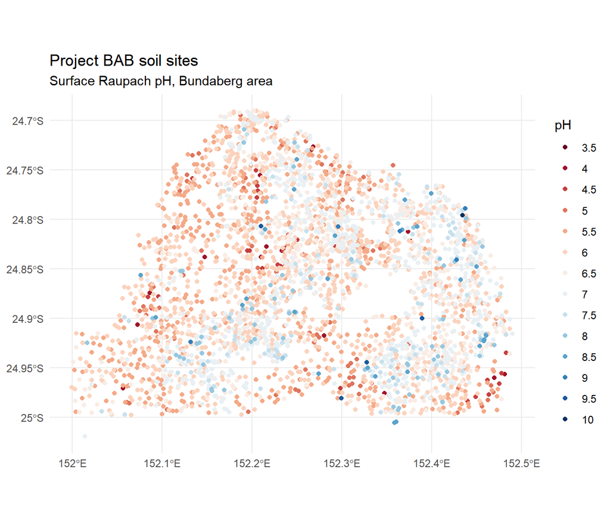

```r
sph_bab <- dplyr::filter(sit_data[['SIT_FIELD_TESTS']], PROJECT_CODE == 'BAB' &
                         TEST_TYPE == 'PH' & OBS_NO == 1 &
                           HORIZON_NO  == 1 & TEST_NO == 1) %>%
  left_join(., SIT_LOCATIONS, by = c('PROJECT_CODE', 'SITE_ID', 'OBS_NO')) %>%
  mutate(VALUE = as.numeric(VALUE),
         VALUE = factor(VALUE, levels = sort(unique(VALUE)), ordered = TRUE)) %>%
  st_as_sf(crs = 4283)

phpal <- colorRampPalette(RColorBrewer::brewer.pal(11, 'RdBu'))

ggplot() +
  geom_sf(data = sph_bab, aes(col = VALUE), pch = 16, show.legend = 'point') +
  scale_colour_manual(values = phpal(14)) +
  labs(col = 'pH') +
  ggtitle('Project BAB soil sites',
          subtitle = 'Surface Raupach pH, Bundaberg area') +
  theme_minimal()
```